# 690C HW2 Network Analysis

Amber Bellou

```r
# Load libraries
library(igraph)
library(tidyverse)
library(ggraph)
```

```r
# Load necessary library
library(igraph)

# Load the graphml files
peru_graph <- read_graph("peru.graphml", format = "graphml")
seattle_graph <- read_graph("seattle.graphml", format = "graphml")
fifa_graph <- read_graph("fifa_country_proj.graphml", format = "graphml")
```

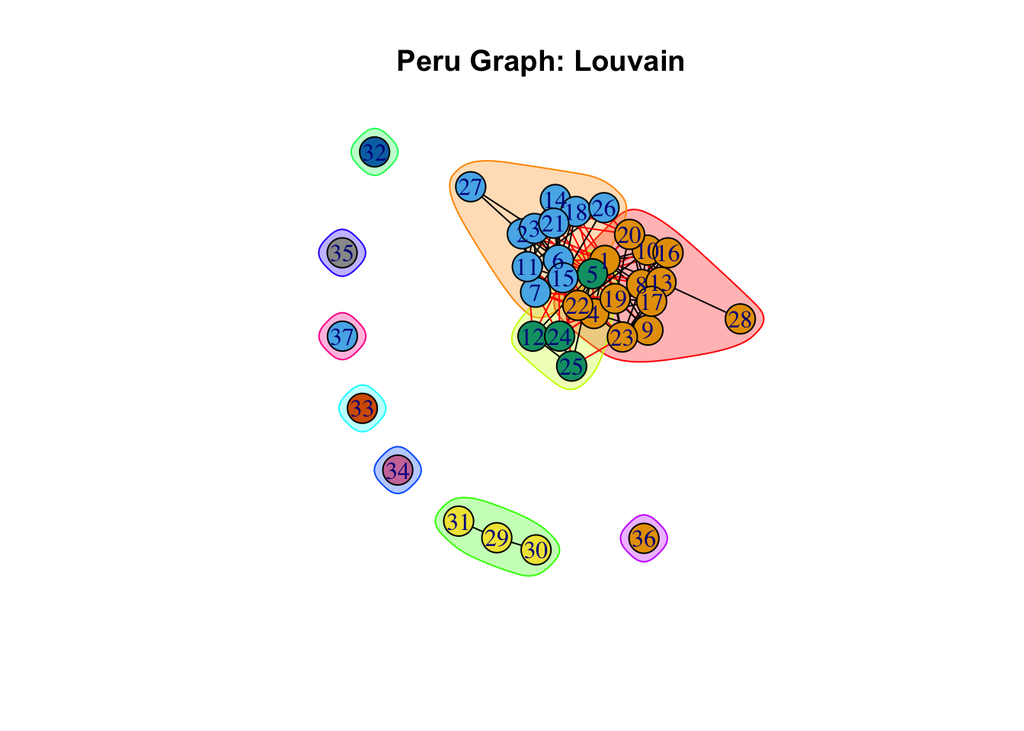

```r
# Louvain
peru_louvain <- cluster_louvain(peru_graph)
plot(peru_louvain, peru_graph, main = "Peru Graph: Louvain")
```

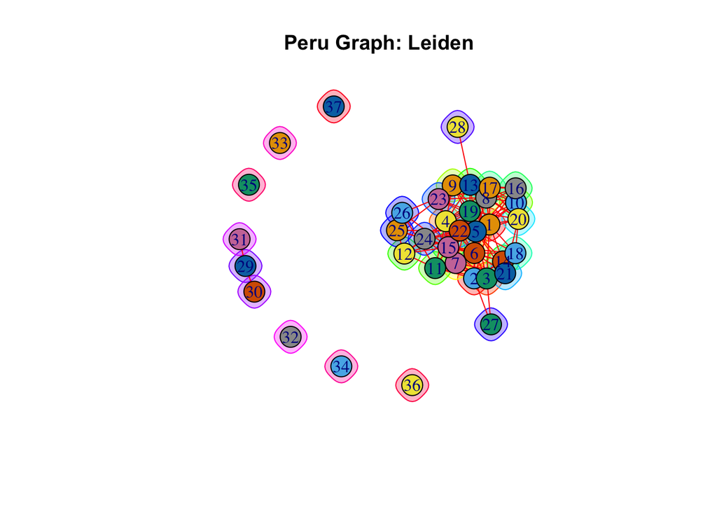

```r
# Leiden
peru_leiden <- cluster_leiden(peru_graph)
plot(peru_leiden, peru_graph, main = "Peru Graph: Leiden")
```

```r
# Try Louvain
try({
  seattle_louvain <- cluster_louvain(seattle_graph)
  plot(seattle_louvain, seattle_graph, main = "Seattle Graph: Louvain")
})
```

```
## Error in cluster_louvain(seattle_graph) :
##   At vendor/cigraph/src/community/louvain.c:615 : Multi-level community detection works for undirected graphs only. Unimplemented function call
```

```r
# Try Leiden
try({
  seattle_leiden <- cluster_leiden(seattle_graph)
  plot(seattle_leiden, seattle_graph, main = "Seattle Graph: Leiden")
})
```

```
## Error in cluster_leiden(seattle_graph) :
##   At vendor/cigraph/src/community/leiden.c:1000 : Leiden algorithm is only implemented for undirected graphs. Invalid value
```

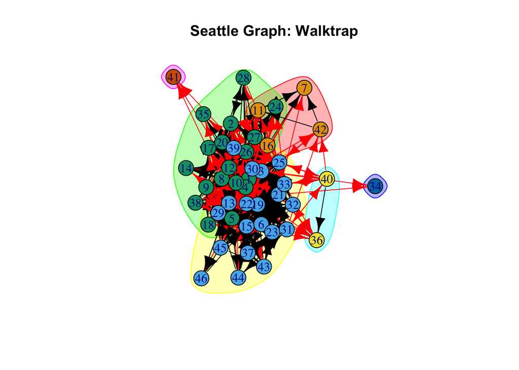

```r
# Walktrap
seattle_walktrap <- cluster_walktrap(seattle_graph)
plot(seattle_walktrap, seattle_graph, main = "Seattle Graph: Walktrap")
```

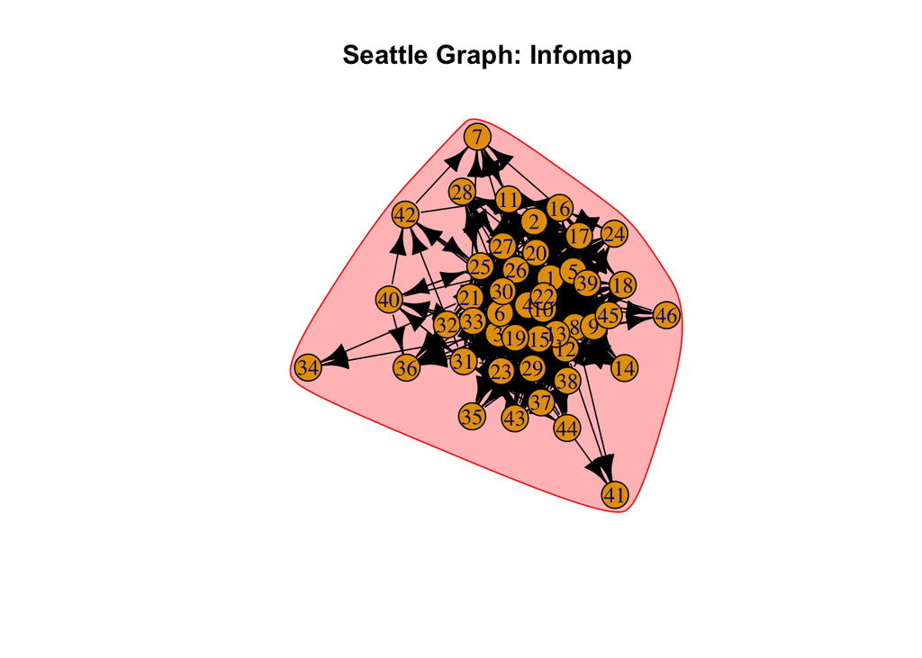

```r
# Infomap
seattle_infomap <- cluster_infomap(seattle_graph)
plot(seattle_infomap, seattle_graph, main = "Seattle Graph: Infomap")
```

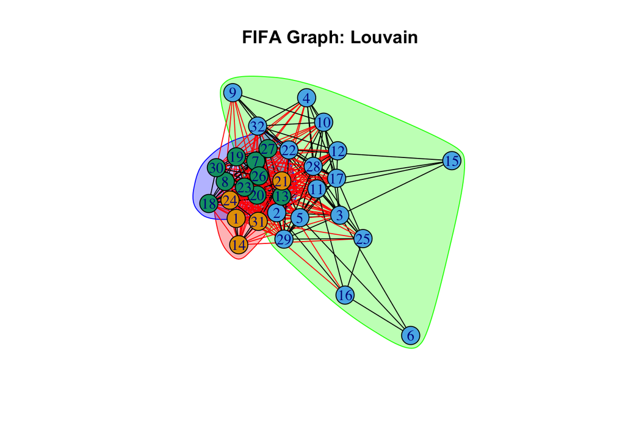

```r
# Louvain
fifa_louvain <- cluster_louvain(fifa_graph)
plot(fifa_louvain, fifa_graph, main = "FIFA Graph: Louvain")
```

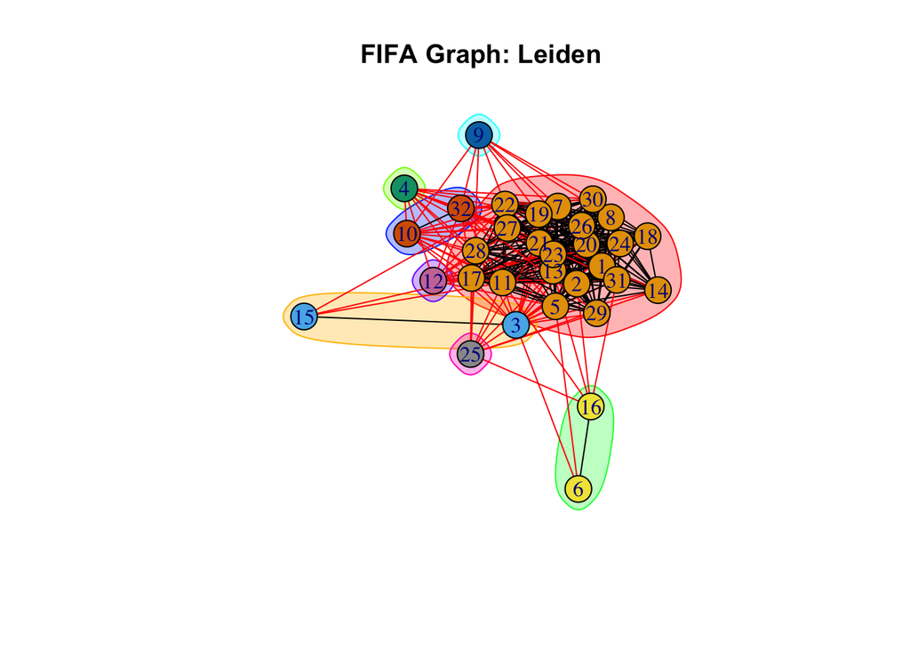

```r
# Leiden
fifa_leiden <- cluster_leiden(fifa_graph)
plot(fifa_leiden, fifa_graph, main = "FIFA Graph: Leiden")
```

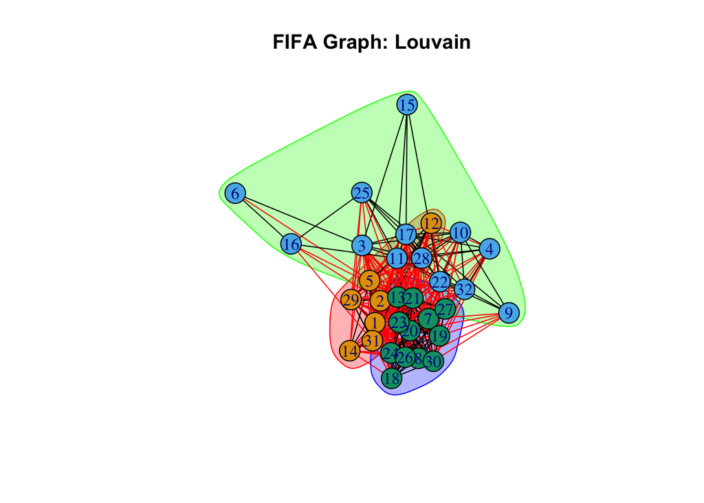

```r
# Louvain
fifa_louvain <- cluster_louvain(fifa_graph)
plot(fifa_louvain, fifa_graph, main = "FIFA Graph: Louvain")
```

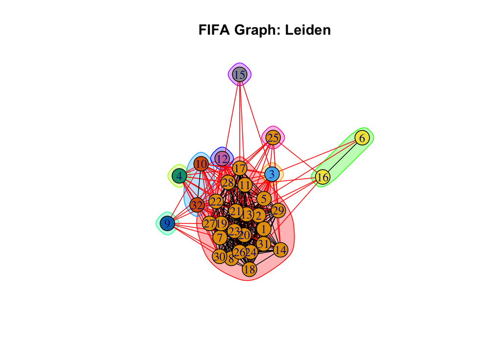

```r
# Leiden
fifa_leiden <- cluster_leiden(fifa_graph)
plot(fifa_leiden, fifa_graph, main = "FIFA Graph: Leiden")
```

```r
# Save plots to files (optional)
png("fifa_louvain.png", width = 800, height = 600)
plot(fifa_louvain, fifa_graph, main = "FIFA Graph: Louvain")
dev.off()
```

```r
png("fifa_leiden.png", width = 800, height = 600)
plot(fifa_leiden, fifa_graph, main = "FIFA Graph: Leiden")
dev.off()
```

```r
length(peru_louvain)
```

```
## [1] 10
```

```r
length(peru_leiden)
```

```
## [1] 37
```

```r
length(seattle_infomap)
```

```
## [1] 1
```

```r
length(seattle_walktrap)
```

```
## [1] 6
```

```r
length(fifa_louvain)
```

```
## [1] 3
```

```r
length(fifa_leiden)
```

```
## [1] 9
```

```r
# Save Peru Louvain Plot
png("peru_louvain.png", width = 800, height = 600)
plot(peru_louvain, peru_graph, main = "Peru Graph: Louvain")
dev.off()
```

```r
# Save Peru Leiden Plot
png("peru_leiden.png", width = 800, height = 600)
plot(peru_leiden, peru_graph, main = "Peru Graph: Leiden")
dev.off()
```

```r
# Save Seattle Walktrap Plot
png("seattle_walktrap.png", width = 800, height = 600)
plot(seattle_walktrap, seattle_graph, main = "Seattle Graph: Walktrap")
dev.off()
```

```r
# Save Seattle Infomap Plot
png("seattle_infomap.png", width = 800, height = 600)
plot(seattle_infomap, seattle_graph, main = "Seattle Graph: Infomap")
dev.off()
```

```r
# Load igraph (in case it was cleared or restarted)
library(igraph)

# Calculate Modularity Scores
mod_peru_louvain <- modularity(peru_graph, membership(peru_louvain))
mod_peru_leiden <- modularity(peru_graph, membership(peru_leiden))

mod_seattle_walktrap <- modularity(seattle_graph, membership(seattle_walktrap))
mod_seattle_infomap <- modularity(seattle_graph, membership(seattle_infomap))

mod_fifa_louvain <- modularity(fifa_graph, membership(fifa_louvain))
mod_fifa_leiden <- modularity(fifa_graph, membership(fifa_leiden))

# Print scores
mod_peru_louvain
```

```
## [1] 0.2886145
```

```r
mod_peru_leiden
```

```
## [1] -0.04142661
```

```r
mod_seattle_walktrap
```

```
## [1] 0.09260031
```

```r
mod_seattle_infomap
```

```
## [1] 0
```

```r
mod_fifa_louvain
```

```
## [1] 0.04438592
```

```r
mod_fifa_leiden
```

```
## [1] 0.01058855
```

## Conclusion

This assignment explored community detection in three network graphs — Peru, Seattle, and FIFA — using Louvain, Leiden, Walktrap, and Infomap algorithms. Each graph varied in structure and connectivity, which affected the performance and suitability of the algorithms. Below are the results and my recommended choices based on modularity scores and clustering granularity.

### 🌎 Peru Graph (Undirected)

- **Louvain** detected **10 communities**, with a **modularity of 0.2886**.
- **Leiden** detected **37 communities**, with a **modularity of -0.0414**.

🟩 **Decision:** **Louvain is preferred** here. It produced fewer but more cohesive communities and had a significantly higher modularity score, suggesting it captured stronger and more meaningful groupings.

### 🌆 Seattle Graph (Directed)

- **Walktrap** detected **6 communities**, with a **modularity of 0.0926**.
- **Infomap** detected **1 community**, with a **modularity of 0**.

🟩 **Decision:** **Walktrap is the better choice.** It was able to identify multiple communities and showed non-zero modularity, while Infomap failed to find meaningful structure in the dense, directed graph.

### ⚽ FIFA Graph (Undirected)

🟩 **Decision:** **Louvain is preferred.** Although Leiden found more clusters, Louvain had higher modularity, indicating stronger internal consistency in the groups it identified.

### 🧠 Final Takeaways

- **Louvain** performed best for both the Peru and FIFA graphs, offering stronger modularity and clearer structures.
- **Leiden** offered more granularity but at the cost of lower modularity, which can limit interpretability.
- **Walktrap** was most effective for the directed Seattle graph, outperforming Infomap.
- **Infomap** struggled to detect structure in this dataset and is not recommended here.

➡️ **Overall, Louvain and Walktrap were the most effective algorithms for these networks.**